# Multi-round allocation game: design choice backed by simulation

Ideal Bayesian learner, parameter recovery, and power for four candidate designs

Published

October 16, 2026

## Decision for Ben

The 8-round pilot (March 24 to 26, N = 50) showed no round-1 condition effect and no learning. This memo simulates a redesigned game before launch. It answers one question: **which design lets us estimate each participant’s prior and learning rate well enough to compare conditions?** Pick a design, then say whether to adapt the existing app or rebuild the game.

**Recommendation: two markets plus a belief report every round.** Three results drive it:

1. **Belief reports matter most.** With 200 participants per condition, the twin-vs-control test on the prior mean (H1) has 93% power with belief reports and 45% without them.
2. **The learning-rate test (H2) is underpowered in every design.** Even at 400 per condition, power peaks at 54%. Prior strength is hard to recover from 10 rounds: the best Spearman *r* between true and estimated values is 0.63. Treat H2 as exploratory unless the game gets more rounds or the effect is larger than *d* = 0.30.
3. **The payoff surface is flat.** Under the S-curve, the revenue-maximising share moves only from 48% (control prior) to 55% (truth). Allocations alone therefore carry little information about beliefs. A steeper payoff (a smaller half-saturation point or a larger size gap between markets) would raise power for the allocation-only tests.

## Why the current game cannot show learning about Republicans

In the current 4-market engine, payoffs depend far more on hidden competition than on party receptivity. Across the four towns, log receptivity varies with SD 0.04, while the competition penalty varies with SD 0.56. Revenue feedback therefore teaches participants about competition, which the twin chat says nothing about. The redesign makes party receptivity the only hidden driver of payoff.

## The redesigned game and the learner model

- **Two markets**, one R-leaning (60,000 households) and one D-leaning (40,000), equal competition, same S-curve as today. True receptivity is equal across parties.
- **10 rounds**, $100,000 per round, at least 5% to each market so both markets always return feedback.
- **Learner.** Each participant holds a belief about R receptivity relative to D (log ratio). The belief starts at a prior mean (*mu0*) with a prior strength (*n0*, in rounds of feedback). After each round, the belief moves toward the observed revenue ratio by 1 / (*n0* + round). A high *n0* means slow learning.
- **Choice.** Participants allocate the revenue-maximising share for their current belief, plus noise (SD = 10 points of budget).
- **Optional belief report.** Each round, before allocating, participants state how many of 100 households in each market would buy.

Under the true parameters, the best plan puts 55% of the budget into the R market. A participant at the assumed control prior puts 48% there, and one at the assumed twin prior puts 50%.

**Planning assumptions (not data).** Control participants believe Republicans are 60% as receptive as Democrats (SD 0.35 on the log ratio) and hold that belief with a strength of about 4 rounds of feedback. The twin chat shifts the prior mean by *d* = 0.30 (H1) and weakens prior strength by *d* = 0.30 (H2). The 4-market variants add the hidden-competition noise of the current engine to every round of feedback.

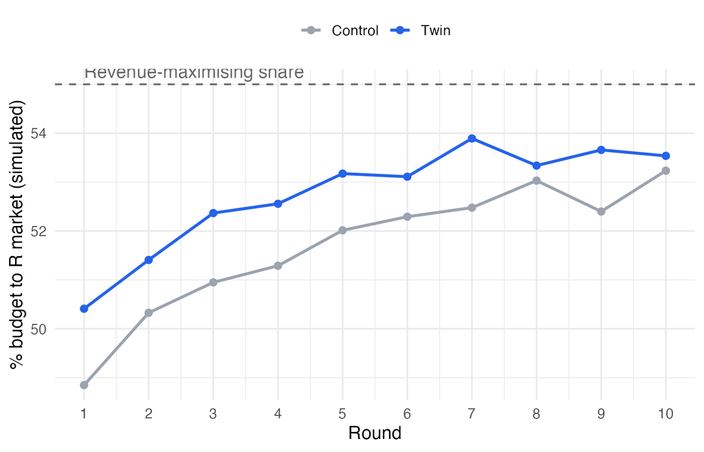

Simulated share of budget to the R market, by round (2-market design with belief reports, 1500 simulated participants per condition).

## Parameter recovery

Recovery is the correlation between each simulated participant’s true parameter and the value the model estimates from their 10 rounds. Values near 1 mean the design can measure the parameter for individuals.

| Design | Prior mean, r | Prior strength, Spearman r | Prior strength at bound |
| --- | --- | --- | --- |
| 2-market + belief reports | 0.94 | 0.53 | 6% |
| 2-market, allocation only | 0.53 | 0.14 | 3% |
| 4-market + belief reports | 0.95 | 0.63 | 4% |
| 4-market, allocation only | 0.56 | 0.16 | 4% |

## Power

Power is the share of 500 resampled experiments with *p* < .05 (Wilcoxon test, twin vs. control). H1 is tested two ways: on the model’s prior mean, and model-free on round-1 allocation.

| Design | Test | N/cell = 100 | N/cell = 150 | N/cell = 200 | N/cell = 300 | N/cell = 400 |
| --- | --- | --- | --- | --- | --- | --- |
| 2-market, allocation only | H1: prior mean (model) | 24% | 34% | 45% | 61% | 77% |
| 2-market, allocation only | H2: prior strength (model) | 6% | 7% | 6% | 11% | 11% |
| 2-market, allocation only | H1: round-1 share (model-free) | 17% | 19% | 28% | 36% | 47% |
| 2-market + belief reports | H1: prior mean (model) | 73% | 88% | 93% | 99% | 100% |
| 2-market + belief reports | H2: prior strength (model) | 16% | 22% | 25% | 37% | 54% |
| 2-market + belief reports | H1: round-1 share (model-free) | 17% | 23% | 31% | 43% | 57% |
| 4-market, allocation only | H1: prior mean (model) | 29% | 38% | 52% | 72% | 87% |
| 4-market, allocation only | H2: prior strength (model) | 7% | 9% | 8% | 12% | 12% |
| 4-market, allocation only | H1: round-1 share (model-free) | 18% | 20% | 29% | 40% | 50% |
| 4-market + belief reports | H1: prior mean (model) | 31% | 56% | 65% | 83% | 94% |
| 4-market + belief reports | H2: prior strength (model) | 14% | 17% | 24% | 35% | 49% |
| 4-market + belief reports | H1: round-1 share (model-free) | 11% | 21% | 26% | 36% | 45% |

## Reading the results

- **H1 (prior mean)** at 200 per cell: 93% power with the 2-market design and belief reports, versus 52% with today’s 4-market layout and allocations only.
- **H2 (learning rate)** at 400 per cell: 54% power with the 2-market design and belief reports, versus 12% with the 4-market layout and allocations only.
- **Model-free round-1 test** at 200 per cell with the 2-market design: 31%.

## Open choices for Ben

1. **Design:** 2-market or 4-market; with or without per-round belief reports.
2. **Build:** adapt the existing chat-plus-game app minimally (swap the market table and payoff, add the belief question, log per-market revenue each round) or rebuild the game.
3. **Assumptions to check:** the H1 and H2 effect sizes (*d* = 0.30) and the 10-point allocation noise drive every power number above. The March pilot data in MongoDB can calibrate allocation noise before launch.

Code: `simulate.R` (writes `output/`). Rerun with `Rscript simulate.R output`.